# Social Referencing and Uncertainty

Emily & Mike

2016-06-02

Data analysis of social referencing and uncertainty study.

# 1 Data preprocessing

Preliminaries.

```
## [1] "dplyr"   "langcog" "tidyr"   "ggplot2" "lme4"
```

Read in files and consolidate to the same directory.

```r
files <- dir("../datavyu/data/")
d.raw <- data.frame()

for (f in files) {
  jf <- paste("../datavyu/data/",f,sep="")
  jd <- read.csv(jf)
  id <- data.frame(SID = f,
                   line = jd$phase.ordinal,
                   phase = as.numeric(jd$phase.1_2_3_4),
                   phase_onset = jd$phase.onset,
                   phase_offset = jd$phase.offset,
                   num_looks = jd$reference.num_looks,
                   exclude = jd$reference.exclude.)
  d.raw <- bind_rows(d.raw, id)
}

d.raw$SID <- str_replace(d.raw$SID, ".csv", "")
```

Read in trial info and demographics.

```r
demo <- read.csv("../soc_ref_uncertainty_EH_demo2016.csv")
demo$age <- str_replace(demo$age, "n/a", "")
demo$age <- str_replace(demo$age, "N/A", "")
demo$age <- as.numeric(demo$age)
demo$age_years <- trunc(demo$age, digits = 0)
demo$age_months <- demo$age*12

trial_info <- read.csv("trial_info.csv")
```

Join trial info and demographics with raw data.

```r
d <- left_join(d.raw, demo) %>%
  select(SID, phase, num_looks, exclude, age_years, age_months, gender, line, Condition, phase_onset, phase_offset) %>%
  mutate(phase_length = phase_offset - phase_onset) %>%
  mutate(social_ref = as.numeric(num_looks>0))%>%
  left_join(trial_info, by = c("Condition","line"))
```

Calculate social ref, num looks, and exclude for a new phase that collapses across phases 2-3

```r
sr_phase <- d %>%
    select(SID, trial, social_ref, phase_name) %>%
    group_by(SID, trial) %>%
    spread(phase_name, social_ref) %>%
    mutate(request_touch = pmax(request_slide, slide_touch))%>%
    gather("phase_name", "social_ref", label_request:request_touch)

nl_phase <- d %>%
    select(SID, trial, num_looks, phase_name) %>%
    group_by(SID, trial) %>%
    spread(phase_name, num_looks) %>%
    mutate(request_touch = request_slide + slide_touch)%>%
    gather("phase_name", "num_looks", label_request:request_touch)

ex_phase <- d %>%
    select(SID, trial, exclude, phase_name) %>%
    group_by(SID, trial) %>%
    spread(phase_name, exclude) %>%
    mutate(request_touch = pmax(request_slide, slide_touch))%>%
    gather("phase_name", "exclude", label_request:request_touch)

lgth_phase <- d %>%
    select(SID, trial, phase_name, phase_length) %>%
    group_by(SID, trial) %>%
    spread(phase_name, phase_length) %>%
    mutate(request_touch = pmax(request_slide, slide_touch))%>%
    gather("phase_name", "phase_length", label_request:request_touch)
```

Create dataframe with new phase collapsed across phases 2 and 3

```r
dc <- d %>%
  select(SID, trial, social_ref, phase_name, phase_length, familiarity, num_objs, age_months, age_years) %>%
  spread(phase_name, social_ref) %>%
  mutate(request_touch = NA)%>%
  group_by(SID, trial)%>%
  select(SID, trial, familiarity, num_objs, age_months, age_years, label_request, request_touch, touch_response)%>%
  gather("phase_name", "social_ref", label_request:touch_response)%>%
  select(SID, trial, familiarity, num_objs, age_months, age_years, phase_name)%>%
  left_join(sr_phase, by = c("SID", "trial", "phase_name"))%>%
  left_join(nl_phase, by = c("SID", "trial", "phase_name"))%>%
  left_join(ex_phase, by = c("SID", "trial", "phase_name"))%>%
  left_join(lgth_phase, by = c("SID", "trial", "phase_name"))
```

Plot social referencing by familiarity and # items with 4 time bins.

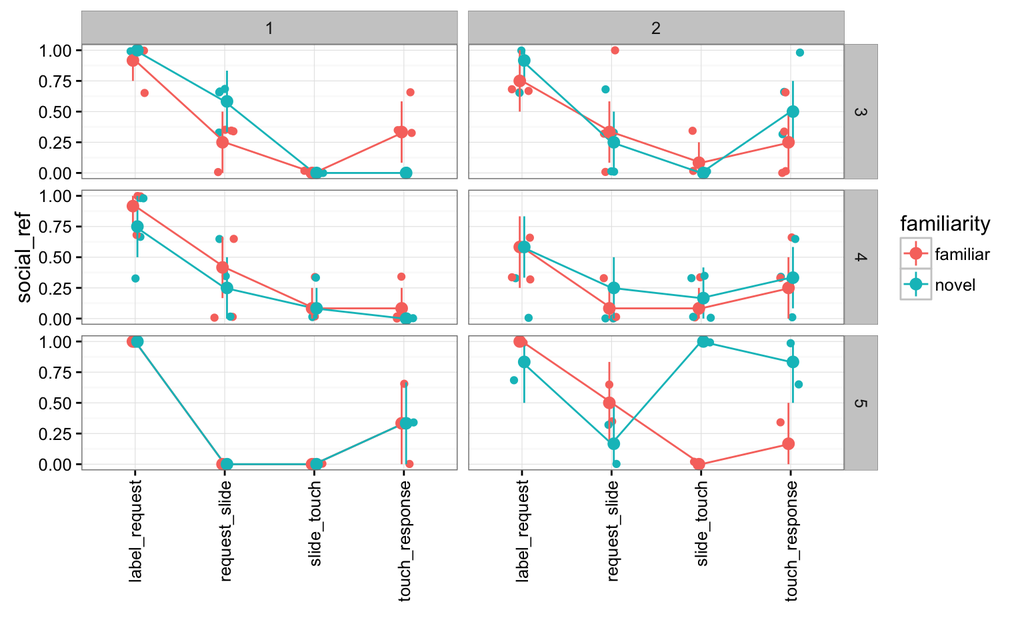

```r
#get means for participants by condition for social ref
mss <- d %>%
  group_by(SID, phase_name, num_objs, familiarity, age_years) %>%
  summarise(social_ref = mean(social_ref))

#get means and CIs across participants for social ref
ms <- d %>%
  group_by(phase_name, familiarity, num_objs, age_years) %>%
  multi_boot_standard(col = "social_ref")

#get means for participants by condition for number of looks
msslooks <- d %>%
  group_by(SID, phase_name, num_objs, familiarity, age_years) %>%
  summarise(num_looks = mean(num_looks))

#get means and CIs across participants for number of looks
mslooks <- d %>%
  group_by(phase_name, familiarity, num_objs, age_years) %>%
  multi_boot_standard(col = "num_looks")

#plot presence or absence of social referencing.
ggplot(mss, aes(x = phase_name, y = social_ref,
               col = familiarity, group = familiarity)) +
  geom_jitter(width = .3, height = .05) +
  geom_line(data = ms, aes(y = mean)) +
  geom_pointrange(data = ms,
                  aes(y = mean, ymin = ci_lower, ymax = ci_upper),
                  position = position_dodge(width =.1)) +
  facet_grid(age_years ~ num_objs) +
  ylim(c(0,1)) +
  xlab("") +
  theme(axis.text.x = element_text(angle = 90, hjust = 1, vjust = .5))
```

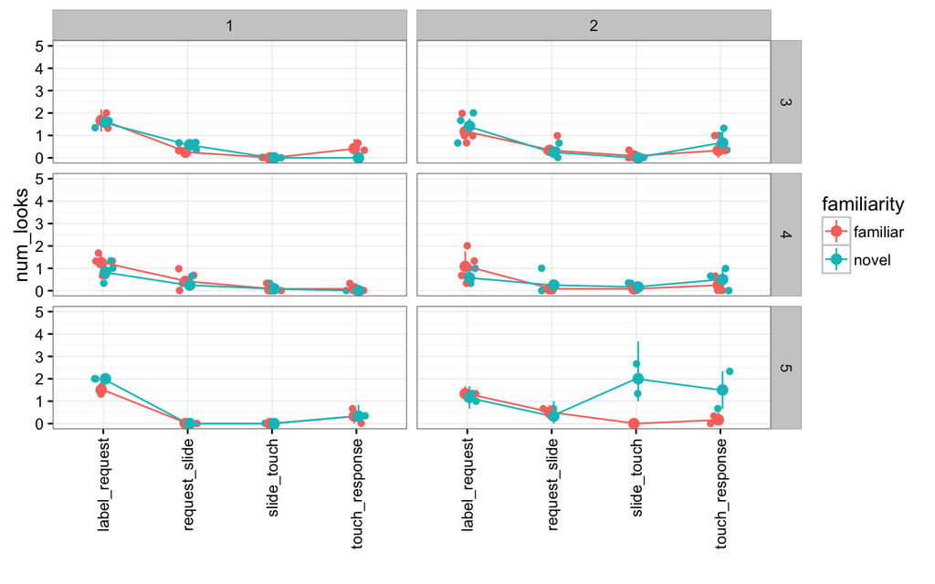

```r
#plot number of looks.
ggplot(msslooks, aes(x = phase_name, y = num_looks,
               col = familiarity, group = familiarity)) +
  geom_jitter(width = .3, height = .05) +
  geom_line(data = mslooks, aes(y = mean)) +
  geom_pointrange(data = mslooks,
                  aes(y = mean, ymin = ci_lower, ymax = ci_upper),
                  position = position_dodge(width =.1)) +
  facet_grid(age_years ~ num_objs) +
  ylim(c(0,5)) +
  xlab("") +
  theme(axis.text.x = element_text(angle = 90, hjust = 1, vjust = .5))
```

Get phase lengths.

```r
phase_lengths <- d %>%
  group_by(phase_name) %>%
  summarise(phase_length = mean(phase_length)) %>%
  mutate(time = cumsum(phase_length),
         middle_time = time - phase_length/2,
         middle_time_s = middle_time / 1000)

ms <- left_join(ms, phase_lengths)
mss <- left_join(mss, phase_lengths)

#plot to include phase lenghts.
# ggplot(mss, aes(x = middle_time_s, y = social_ref,
#                col = familiarity, group = familiarity)) +
#   geom_jitter(width = .4, height = .05) +
#   geom_line(data = ms, aes(y = mean)) +
#   geom_pointrange(data = ms,
#                   aes(y = mean, ymin = ci_lower, ymax = ci_upper),
#                   position = position_dodge(width =.1)) +
#   facet_grid(.~num_objs) +
#   ylim(c(0,1)) +
#   xlim(c(0, 9)) +
#   xlab("Time (s)") +
#   ylab("Probability of social referencing") +
#   theme(axis.text.x = element_text(angle = 90, hjust = 1, vjust = .5))
```

Plot average phase lengths.

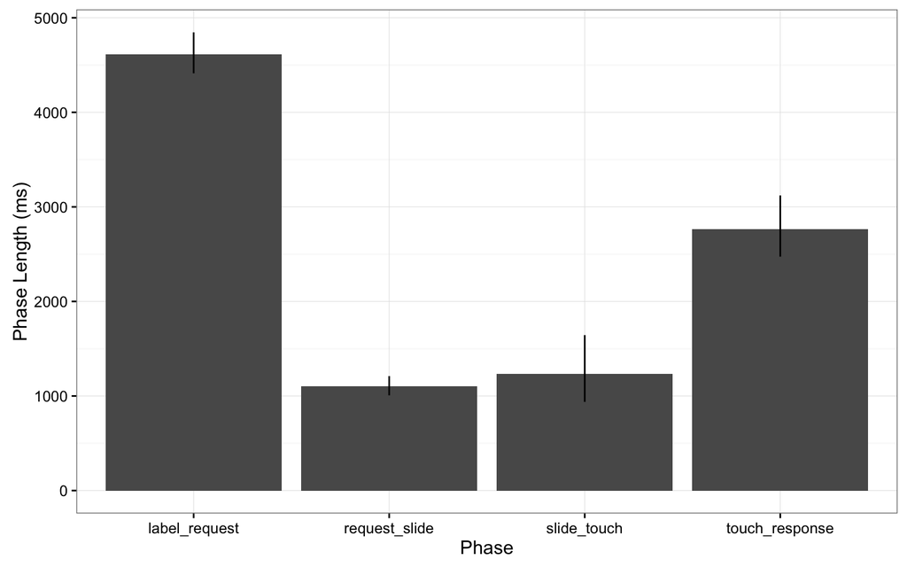

```r
#plot phase lenghts of four phases.
phase_lengths <- d %>%
  group_by(phase_name) %>%
  multi_boot_standard(col = "phase_length")

ggplot(phase_lengths, aes(x = phase_name, y = mean)) +
  geom_bar(stat="identity") +
  geom_linerange(aes(ymin = ci_lower, ymax = ci_upper),
             position = position_dodge(width = .9))+
  xlab("Phase") +
  ylab("Phase Length (ms)")
```

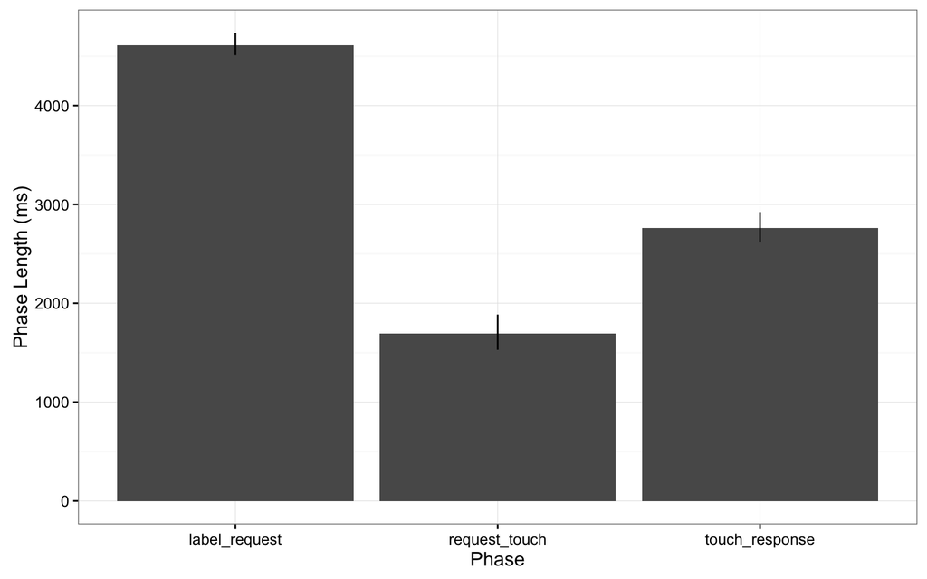

```r
#plot phase lengths for 3 phases (2 and 3 collapsed)
phase_lengths_dc <- dc %>%
  group_by(phase_name) %>%
  multi_boot_standard(col = "phase_length")

ggplot(phase_lengths_dc, aes(x = phase_name, y = mean)) +
  geom_bar(stat="identity") +
  geom_linerange(aes(ymin = ci_lower, ymax = ci_upper),
             position = position_dodge(width = .9))+
  xlab("Phase") +
  ylab("Phase Length (ms)")
```

Plot phase lengths by condition by age. Slide-touch phase can be thought of to reflect decision time.

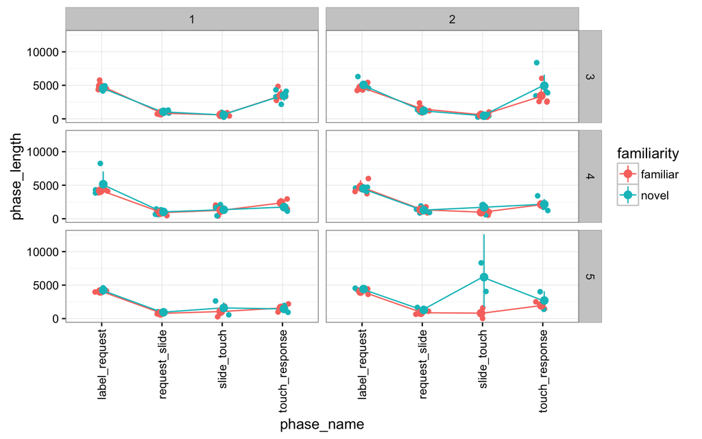

```r
msslengths <- d %>%
  group_by(SID, phase_name, num_objs, familiarity, age_years) %>%
  summarise(phase_length = mean(phase_length))

mslengths <- d %>%
  group_by(phase_name, familiarity, num_objs, age_years) %>%
  multi_boot_standard(col = "phase_length")

ggplot(msslengths, aes(x = phase_name, y = phase_length,
               col = familiarity, group = familiarity)) +
  geom_jitter(width = .3, height = .05) +
  geom_line(data = mslengths, aes(y = mean)) +
  geom_pointrange(data = mslengths,
                  aes(y = mean, ymin = ci_lower, ymax = ci_upper),
                  position = position_dodge(width =.1)) +
  facet_grid(age_years ~ num_objs) +
  theme(axis.text.x = element_text(angle = 90, hjust = 1, vjust = .5))
```

# 2 Planned analyses

Separate mixed-effects linear regression models for 3 phases.

Phase Label-Request

```r
lm <- lmer(num_looks ~ num_objs * familiarity * age_months +
              (1|SID),
              data = filter(dc, exclude == 0, phase_name == "label_request"))

tab <- kable(coef(summary(lm)), caption = "Mixed effects linear regression model predicting social referencing")
print(tab, type="html")
```

Mixed effects linear regression model predicting social referencing

|  | Estimate | Std. Error | t value |
| --- | --- | --- | --- |
| (Intercept) | 3.4294871 | 1.1133614 | 3.080300 |
| num_objs | -1.0709148 | 0.5232158 | -2.046794 |
| familiaritynovel | -2.2263320 | 1.1442974 | -1.945589 |
| age_months | -0.0320531 | 0.0216608 | -1.479777 |
| num_objs:familiaritynovel | 1.3969869 | 0.7286754 | 1.917159 |
| num_objs:age_months | 0.0140548 | 0.0102102 | 1.376547 |
| familiaritynovel:age_months | 0.0422613 | 0.0223009 | 1.895051 |
| num_objs:familiaritynovel:age_months | -0.0272380 | 0.0141963 | -1.918669 |

Phase Request-Touch

```r
lm <- lmer(num_looks ~ num_objs * familiarity * age_months +
              (1|SID),
              data = filter(dc, exclude == 0, phase_name == "request_touch"))

tab <- kable(coef(summary(lm)), caption = "Mixed effects linear regression model predicting social referencing")
print(tab, type="html")
```

Mixed effects linear regression model predicting social referencing

|  | Estimate | Std. Error | t value |
| --- | --- | --- | --- |
| (Intercept) | 0.6014055 | 0.9862466 | 0.6097922 |
| num_objs | -0.2840311 | 0.5583471 | -0.5086998 |
| familiaritynovel | 4.7742499 | 1.2162326 | 3.9254416 |
| age_months | -0.0084128 | 0.0192868 | -0.4361944 |
| num_objs:familiaritynovel | -3.7988745 | 0.7738496 | -4.9090602 |
| num_objs:age_months | 0.0074588 | 0.0109265 | 0.6826307 |
| familiaritynovel:age_months | -0.0972613 | 0.0237191 | -4.1005401 |
| num_objs:familiaritynovel:age_months | 0.0800105 | 0.0150806 | 5.3055178 |

Phase Touch-Response

```r
lm <- lmer(num_looks ~ num_objs * familiarity * age_months +
              (1|SID),
              data = filter(dc, exclude == 0, phase_name == "touch_response"))

tab <- kable(coef(summary(lm)), caption = "Mixed effects linear regression model predicting social referencing")
print(tab, type="html")
```

Mixed effects linear regression model predicting social referencing

|  | Estimate | Std. Error | t value |
| --- | --- | --- | --- |
| (Intercept) | 0.6682390 | 0.8445714 | 0.7912167 |
| num_objs | -0.1057191 | 0.4427632 | -0.2387712 |
| familiaritynovel | -1.3726124 | 0.9900485 | -1.3864092 |
| age_months | -0.0078941 | 0.0163836 | -0.4818270 |
| num_objs:familiaritynovel | 0.3766758 | 0.6261617 | 0.6015632 |
| num_objs:age_months | 0.0020782 | 0.0085890 | 0.2419612 |
| familiaritynovel:age_months | 0.0092906 | 0.0192057 | 0.4837404 |
| num_objs:familiaritynovel:age_months | 0.0063559 | 0.0121467 | 0.5232575 |

Omnibus model. Confirmitory plan is to look for 4-way interaction between number of ojects (1 vs 2), familiarity (novel vs familiar), phase (label vs request vs response). Study may be underpowered to detect 4-way interaction.

```r
lm <- lmer(num_looks ~ num_objs * familiarity * phase_name * age_months +
              (1|SID),
              data = filter(dc, exclude == 0))

tab <- kable(coef(summary(lm)), caption = "Mixed effects linear regression model predicting social referencing")
print(tab, type="html")
```

Mixed effects linear regression model predicting social referencing

|  | Estimate | Std. Error | t value |
| --- | --- | --- | --- |
| (Intercept) | 3.3940884 | 0.9557772 | 3.5511292 |
| num_objs | -1.0224632 | 0.5257552 | -1.9447513 |
| familiaritynovel | -2.1648275 | 1.1508204 | -1.8811167 |
| phase_namerequest_touch | -2.8608799 | 1.1623576 | -2.4612734 |
| phase_nametouch_response | -2.7258493 | 1.1467339 | -2.3770548 |
| age_months | -0.0312603 | 0.0186136 | -1.6794382 |
| num_objs:familiaritynovel | 1.3354824 | 0.7325654 | 1.8230213 |
| num_objs:phase_namerequest_touch | 0.7637345 | 0.7449965 | 1.0251519 |
| num_objs:phase_nametouch_response | 0.9167441 | 0.7309318 | 1.2542129 |
| familiaritynovel:phase_namerequest_touch | 7.0072744 | 1.6280666 | 4.3040465 |
| familiaritynovel:phase_nametouch_response | 0.7922151 | 1.6166636 | 0.4900309 |
| num_objs:age_months | 0.0129477 | 0.0102594 | 1.2620389 |
| familiaritynovel:age_months | 0.0408400 | 0.0224276 | 1.8209739 |
| phase_namerequest_touch:age_months | 0.0243211 | 0.0227164 | 1.0706434 |
| phase_nametouch_response:age_months | 0.0233663 | 0.0223058 | 1.0475415 |
| num_objs:familiaritynovel:phase_namerequest_touch | -5.1596593 | 1.0359938 | -4.9803958 |
| num_objs:familiaritynovel:phase_nametouch_response | -0.9588066 | 1.0258350 | -0.9346596 |
| num_objs:familiaritynovel:age_months | -0.0258166 | 0.0142714 | -1.8089834 |
| num_objs:phase_namerequest_touch:age_months | -0.0059297 | 0.0145563 | -0.4073652 |
| num_objs:phase_nametouch_response:age_months | -0.0108695 | 0.0142227 | -0.7642404 |
| familiaritynovel:phase_namerequest_touch:age_months | -0.1395749 | 0.0317357 | -4.3980343 |
| familiaritynovel:phase_nametouch_response:age_months | -0.0315494 | 0.0314347 | -1.0036501 |
| num_objs:familiaritynovel:phase_namerequest_touch:age_months | 0.1062679 | 0.0201851 | 5.2646651 |
| num_objs:familiaritynovel:phase_nametouch_response:age_months | 0.0321725 | 0.0199432 | 1.6132108 |

Condition x age predicting decision latency (phase slide-touch).

```r
lm <- lmer(phase_length ~ num_objs * familiarity * age_months +
              (1|SID),
              data = filter(d, exclude == 0, phase_name == "slide_touch"))

tab <- kable(coef(summary(lm)), caption = "Mixed effects linear regression model predicting social referencing")
print(tab, type="html")
```

|  | Estimate | Std. Error | t value |
| --- | --- | --- | --- |
| (Intercept) | -104.238041 | 4900.18571 | -0.0212723 |
| num_objs | 10.393220 | 3005.57731 | 0.0034580 |
| familiaritynovel | 5239.125336 | 6714.31001 | 0.7802924 |
| age_months | 22.274147 | 95.42277 | 0.2334259 |
| num_objs:familiaritynovel | -6395.301203 | 4240.45681 | -1.5081633 |
| num_objs:age_months | -2.573913 | 58.45341 | -0.0440336 |
| familiaritynovel:age_months | -121.712067 | 130.51600 | -0.9325452 |
| num_objs:familiaritynovel:age_months | 148.003205 | 82.36518 | 1.7969147 |